# Tutorial 8: Introduction to Data Visualisation

Programming for Engineers (ENGG1001)

Published

June 25, 2026

## Tutorial Tasks

- Task 1: Plotting Linear and Quadratic Functions
- Task 2: Plotting Ellipses
- Task 3: Plotting and visualising the Wivenhoe flow data
- Task 4: Plotting randomness in data

## Task 1: Plotting Linear and Quadratic Functions

In this task, you will create plots for linear and quadratic functions with matplotlib.

1. Create a function `plot_linear(x_start, x_end, m, c, num_points)` which plots a linear function defined by the equation `y = mx + c` over the range from `x_start` to `x_end` with `num_points` points. The example usage is shown below:

plot_linear(-10, 10, 2, 1, 100)

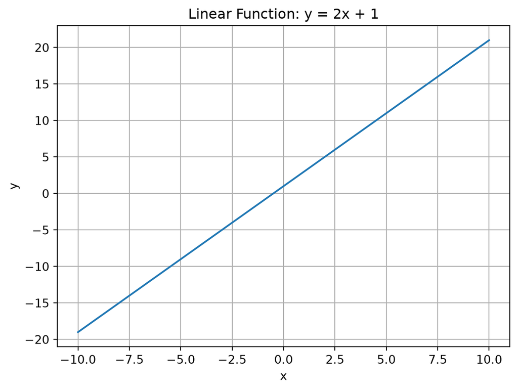

Plot of the linear function y = 2x + 1 from x = -10 to x = 10

**Tip**

Start by creating an array of x values, then compute the corresponding y values using the linear equation.

**Callout-answer**Answer**

```
plot_linear.py
```

```python
import numpy as np
import matplotlib.pyplot as plt

def plot_linear(x_start: float, x_end: float, m: float, c: float, num_points: int) -> None:
    """Plots a linear function y = mx + c over the range [x_start, x_end].

    Parameters
    ----------
    x_start : float
        The starting value of x.
    x_end : float
        The ending value of x.
    m : float
        The slope of the linear function.
    c : float
        The y-intercept of the linear function.
    num_points : int
        The number of points to plot.

    Returns
    -------
    None
    """
    x = np.linspace(x_start, x_end, num_points)
    y = m * x + c
    plt.plot(x, y)
    plt.title(f'Linear Function: y = {m}x + {c}')
    plt.xlabel('x')
    plt.ylabel('y')
    plt.grid()
    plt.show()

plot_linear(-10, 10, 2, 1, 100)
```

Output

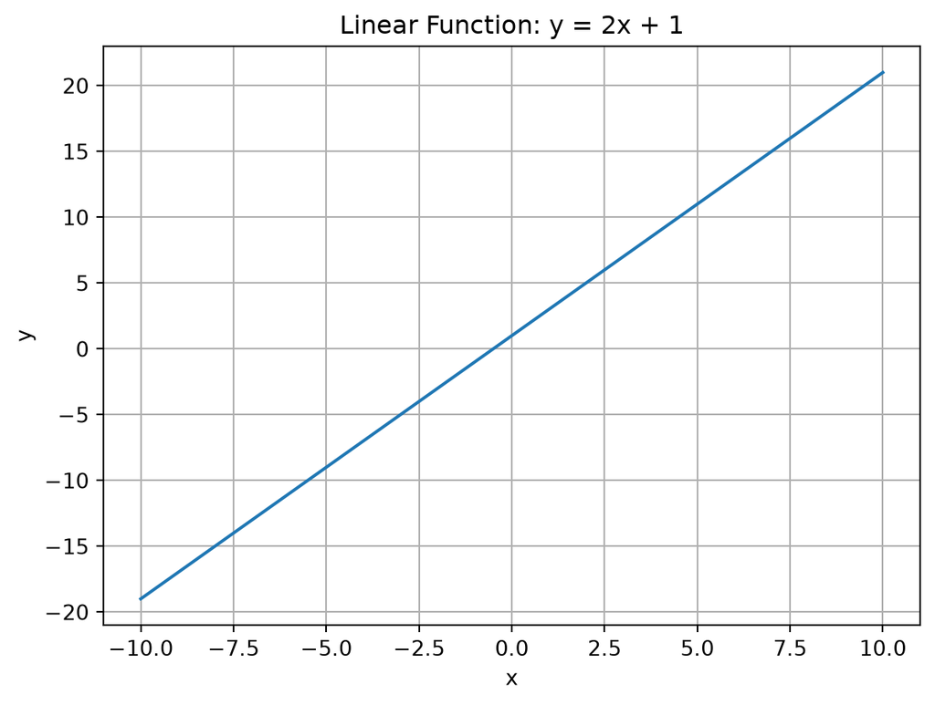

2. Create a function `plot_quadratic(x_start, x_end, a, b, c, num_points)` which plots a quadratic function defined by the equation `y = ax^2 + bx + c` over the range from `x_start` to `x_end` with `num_points` points. The example usage is shown below:

plot_quadratic(-10, 10, 1, 0, 0, 100)

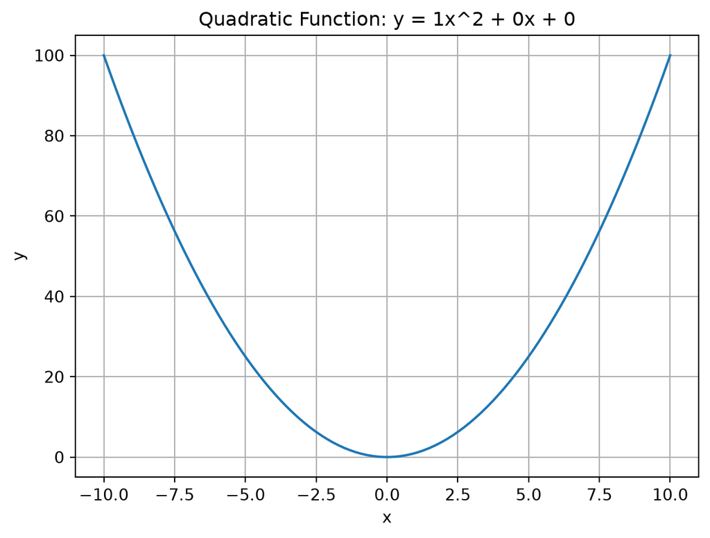

Plot of the quadratic function y = x^2 from x = -10 to x = 10

**Callout-answer**Answer**

```
plot_quadratic.py
```

```python
def plot_quadratic(x_start: float, x_end: float, a: float,
                   b: float, c: float, num_points: int) -> None:
    """Plots a quadratic function y = ax^2 + bx + c over the range [x_start, x_end].

    Parameters
    ----------
    x_start : float
        The starting value of x.
    x_end : float
        The ending value of x.
    a : float
        The coefficient of x^2.
    b : float
        The coefficient of x.
    c : float
        The constant term.
    num_points : int
        The number of points to plot.

    Returns
    -------
    None
    """
    x = np.linspace(x_start, x_end, num_points)
    y = a * x**2 + b * x + c
    plt.plot(x, y)
    plt.title(f'Quadratic Function: y = {a}x^2 + {b}x + {c}')
    plt.xlabel('x')
    plt.ylabel('y')
    plt.grid()
    plt.show()

plot_quadratic(-10, 10, 1, 0, 0, 100)
```

Output

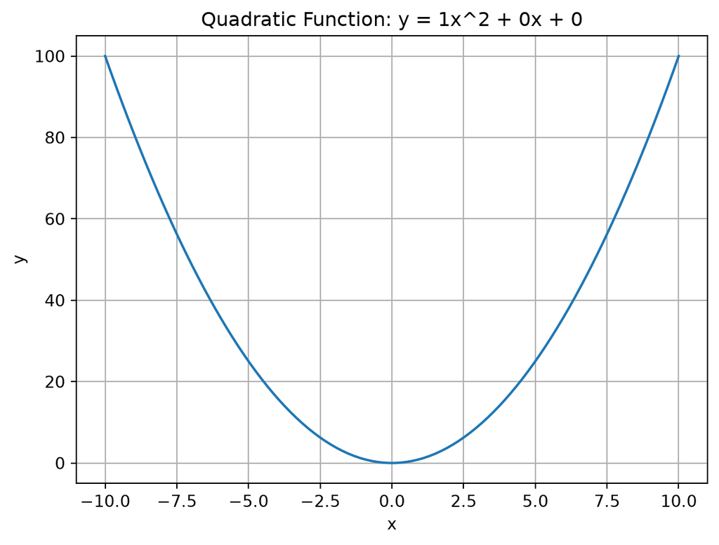

## Task 2: Plotting Ellipses

In this task, you will create plots for ellipses and circles using matplotlib. You might find the following equations helpful:

$$x = a \cos (\theta)$$
$$y = b \sin (\theta)$$

where (a) and (b) are the semi-major and semi-minor axes of the ellipse, respectively, and $\theta$ is the angle parameter.

**Note**

when a = b, the ellipse becomes a circle!

1. Create a function `plot_ellipse(a, b, num_points)` which plots an ellipse with semi-major axis `a` and semi-minor axis `b` using `num_points` points. The example usage is shown below:

plot_ellipse(5, 3, 100)

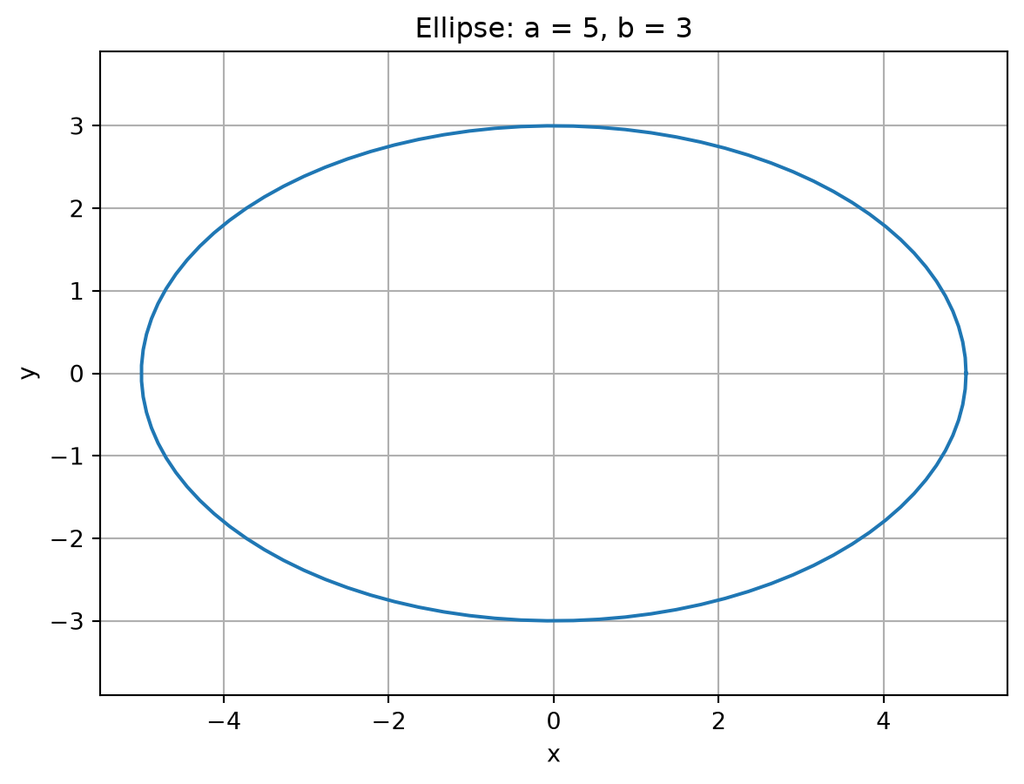

Plot of an ellipse with semi-major axis 5 and semi-minor axis 3

**Callout-answer**Answer**

```
plot_ellipse.py
```

```python
def plot_ellipse(a: float, b: float, num_points: int) -> None:
    """Plots an ellipse with semi-major axis a and semi-minor axis b.

    Parameters
    ----------
    a : float
        The semi-major axis of the ellipse.
    b : float
        The semi-minor axis of the ellipse.
    num_points : int
        The number of points to plot.

    Returns
    -------
    None
    """
    theta = np.linspace(0, 2 * np.pi, num_points)
    x = a * np.cos(theta)
    y = b * np.sin(theta)
    plt.plot(x, y)
    plt.title(f'Ellipse: a = {a}, b = {b}')
    plt.xlabel('x')
    plt.ylabel('y')
    plt.axis('equal')
    plt.grid()
    plt.show()
```

2. Now modify the `plot_ellipse` function to plot the major and minor axes of the ellipse. The major axis is a horizontal line from (-a, 0) to (a, 0), and the minor axis is a vertical line from (0, -b) to (0, b). Label the axes appropriately in the plot. The resulting plot should look like this:

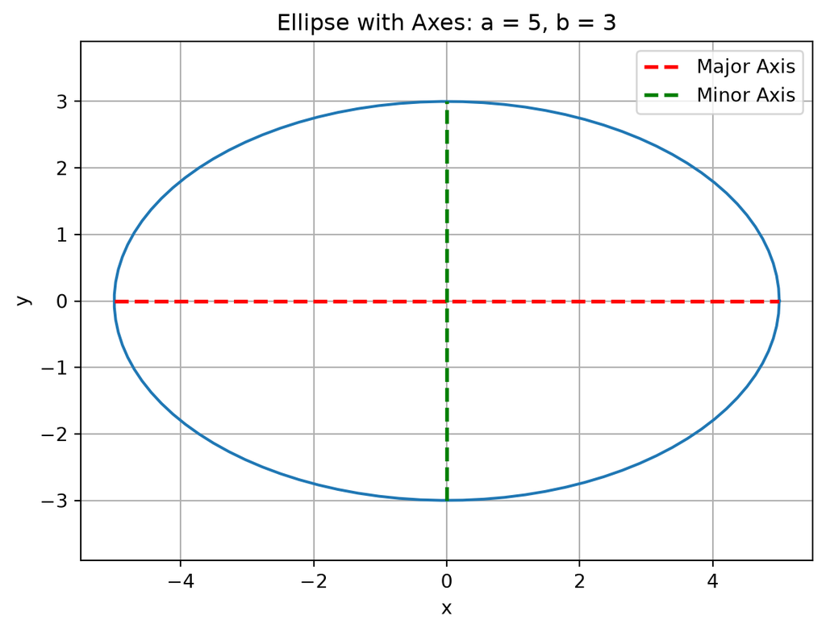

Plot of an ellipse with major and minor axes

**Callout-answer**Answer**

```
plot_ellipse_with_axes.py
```

```python
def plot_ellipse(a: float, b: float, num_points: int) -> None:
    """Plots an ellipse with semi-major axis a and semi-minor axis b,
    along with its major and minor axes.

    Parameters
    ----------
    a : float
        The semi-major axis of the ellipse.
    b : float
        The semi-minor axis of the ellipse.
    num_points : int
        The number of points to plot.

    Returns
    -------
    None
    """
    theta = np.linspace(0, 2 * np.pi, num_points)
    x = a * np.cos(theta)
    y = b * np.sin(theta)
    plt.plot(x, y)

    # Plot major axis
    plt.plot([-a, a], [0, 0], 'r--', label='Major Axis', linewidth=2)
    # Plot minor axis
    plt.plot([0, 0], [-b, b], 'g--', label='Minor Axis', linewidth=2)

    plt.title(f'Ellipse with Axes: a = {a}, b = {b}')
    plt.xlabel('x')
    plt.ylabel('y')
    plt.axis('equal')
    plt.grid()
    plt.legend()
    plt.show()

plot_ellipse(5, 3, 100)
```

Output

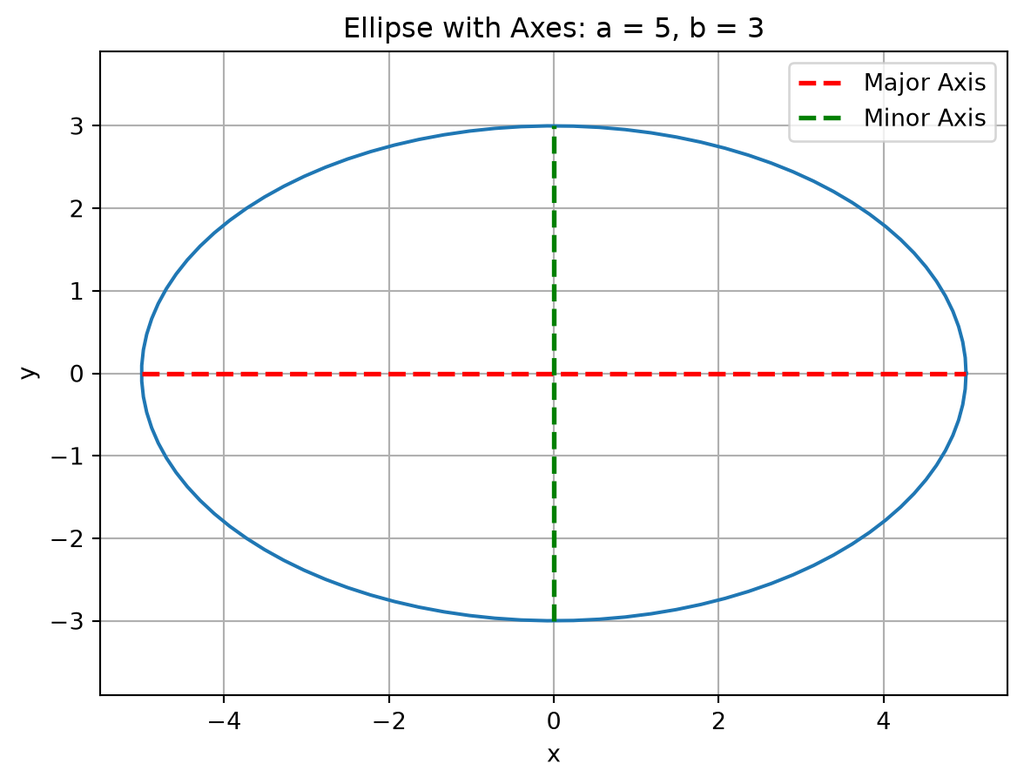

## Task 3: Plotting and visualising the Wivenhoe flow data

In this task, you will visualise the Wivenhoe flow data using matplotlib. The data file is the same as last weeks tutorial, and be downloaded below:

```
flows.csv
```

```
Date,"Somerset inflow, ML","Somerset outflow, ML","Upper Brisbane River, ML","Wivenhoe outflow, ML"
1980-01-01,0,225.4086129,0,676.2258065
1980-01-02,0,225.4086129,0,676.2258065
1980-01-03,0,225.4086129,0,676.2258065
1980-01-04,0,225.4086129,0,676.2258065
... (11045 more lines)
```

1. Create a function `plot_flow_duration(timestamps, flow, date_start, date_end)` which plots the flow data between the specified start and end dates. The example usage is shown below:

timestamps, flow_rates = load_flow_data("flows.csv")

s_in, s_out, ubr, w_out = split_flows(flow_rates)

filtered_s_in = filter_invalid_flows(s_in)

plot_flow_duration(timestamps, filtered_s_in, "2000-01-01", "2000-12-31")

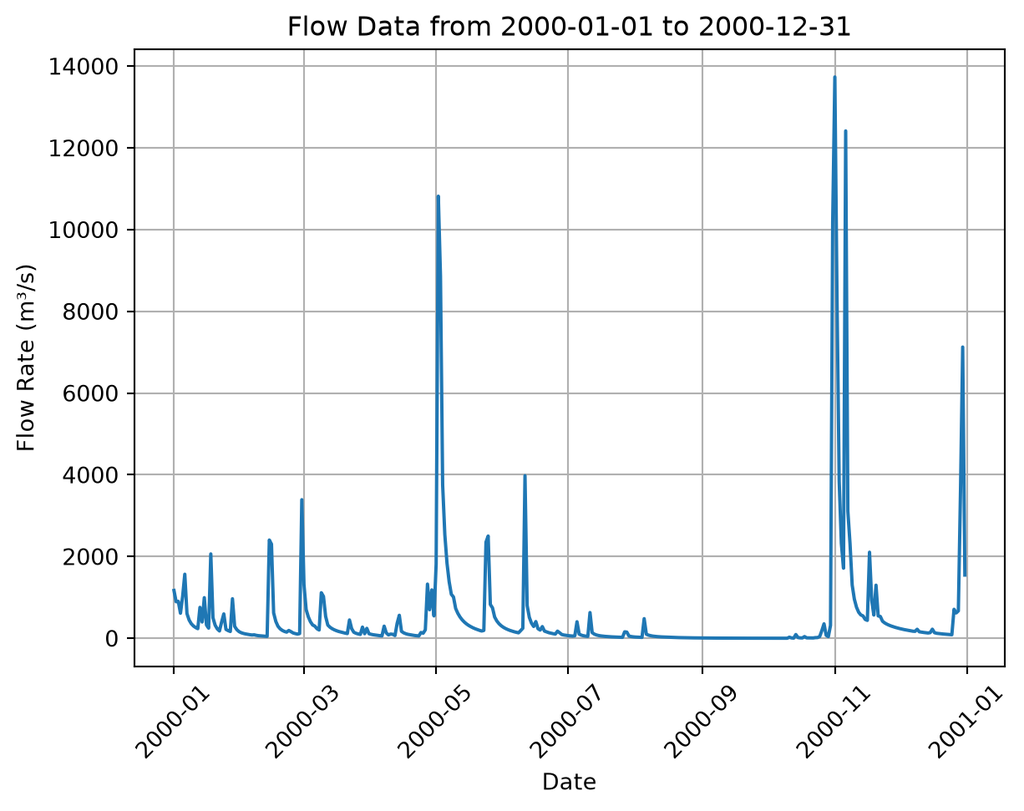

Plot of Wivenhoe flow data for the year 2000

**Tip**

You can use boolean masking to filter the timestamps and flow rates based on the specified date range.

To rotate the x-axis labels for better readability, you can use `plt.xticks(rotation=45)`.

**Callout-answer**Answer**

```
plot_flow_duration.py
```

```python
def plot_flow_duration(timestamps: np.ndarray, flow_rates: np.ndarray,
                       date_start: str, date_end: str) -> None:
    """Plots flow data between specified start and end dates.

    Parameters
    ----------
    timestamps : np.ndarray
        An array of timestamps.
    flow_rates : np.ndarray
        An array of flow rates.
    date_start : str
        The start date in 'YYYY-MM-DD' format.
    date_end : str
        The end date in 'YYYY-MM-DD' format.

    Returns
    -------
    None
    """
    mask = (timestamps >= np.datetime64(date_start)) & (timestamps <= np.datetime64(date_end))
    plt.plot(timestamps[mask], flow_rates[mask])
    plt.title(f'Flow Data from {date_start} to {date_end}')
    plt.xlabel('Date')
    plt.ylabel('Flow Rate (m³/s)')
    plt.xticks(rotation=45)
    plt.grid()
    plt.show()

plot_flow_duration(timestamps, filtered_s_in, "2000-01-01", "2000-12-31")
```

Output

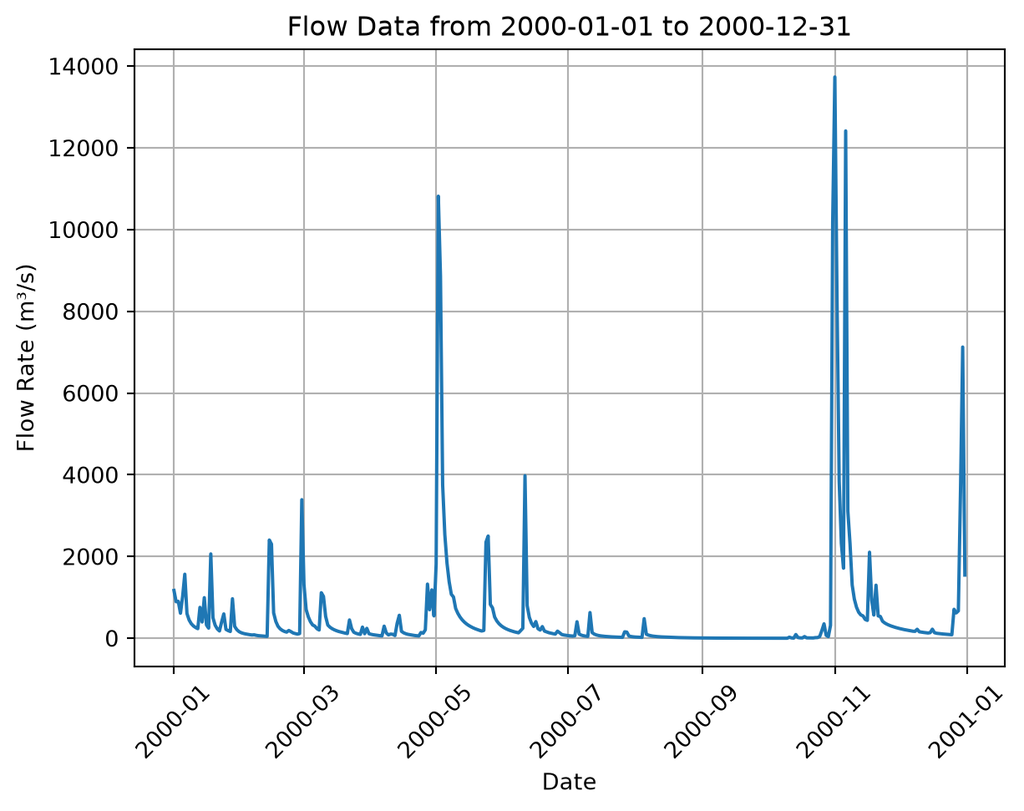

2. Lets try and understand the underlying trends in the flow data. Create a function `plot_flow_correlation(flow_data_1, flow_data_2)` which plots the correlation between two sets of flow data. The example usage is shown below:

timestamps, flow_rates = load_flow_data("flows.csv")

s_in, s_out, ubr, w_out = split_flows(flow_rates)

filtered_s_in = filter_invalid_flows(s_in)

filtered_s_out = filter_invalid_flows(s_out)

plot_flow_correlation(filtered_s_in, filtered_s_out)

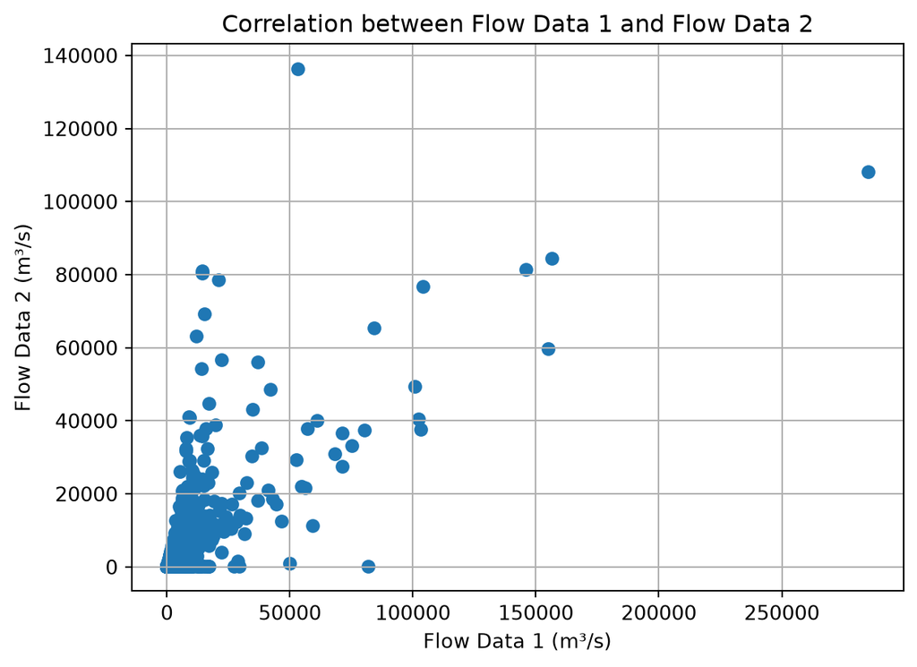

Correlation plot between Somerset inflows and outflows

**Tip**

You can use a scatter plot to visualise the correlation between two sets of flow data. Each point in the scatter plot represents a pair of flow rates from the two datasets.

Try and explore some other correlations for the data, for example, you can plot the correlation between the sum of the inflows (Somerset inflows + Upper Brisbane River inflows) and the outflows (Wivenhoe outflows).

**Callout-answer**Answer**

```
plot_flow_correlation.py
```

```python
def plot_flow_correlation(flow_data_1: np.ndarray, flow_data_2: np.ndarray) -> None:
    """Plots the correlation between two sets of flow data.

    Parameters
    ----------
    flow_data_1 : np.ndarray
        The first set of flow data.
    flow_data_2 : np.ndarray
        The second set of flow data.

    Returns
    -------
    None
    """
    plt.scatter(flow_data_1, flow_data_2)
    plt.title('Correlation between Flow Data 1 and Flow Data 2')
    plt.xlabel('Flow Data 1 (m³/s)')
    plt.ylabel('Flow Data 2 (m³/s)')
    plt.grid()
    plt.show()
timestamps, flow_rates = load_flow_data("resources/flows.csv")
s_in, s_out, ubr, w_out = split_flows(flow_rates)
filtered_s_in = filter_invalid_flows(s_in)
filtered_s_out = filter_invalid_flows(s_out)

plot_flow_correlation(filtered_s_in, filtered_s_out)
```

Output

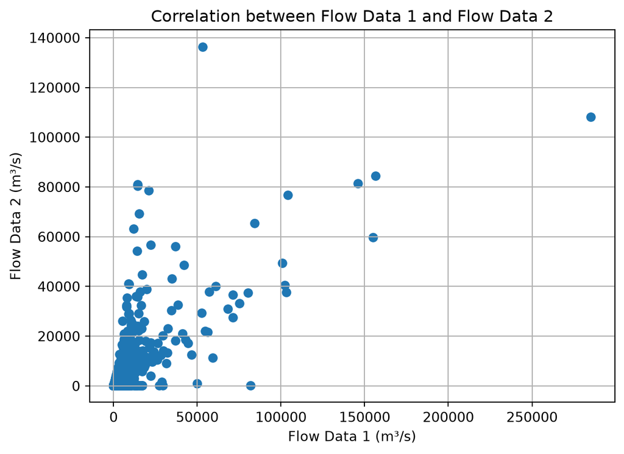

## Task 4: Plotting randomness in data

There are many different types of random distributions that are commonly used in data analysis and statistics. In this task, you will create plots for some of these distributions using matplotlib.

Create a function `plot_random_distribution(distribution_type, num_samples, num_bins)` which plots a random distribution of the specified type with the given number of samples. The example usage is shown below:

plot_random_distribution("normal", 1000, 50)

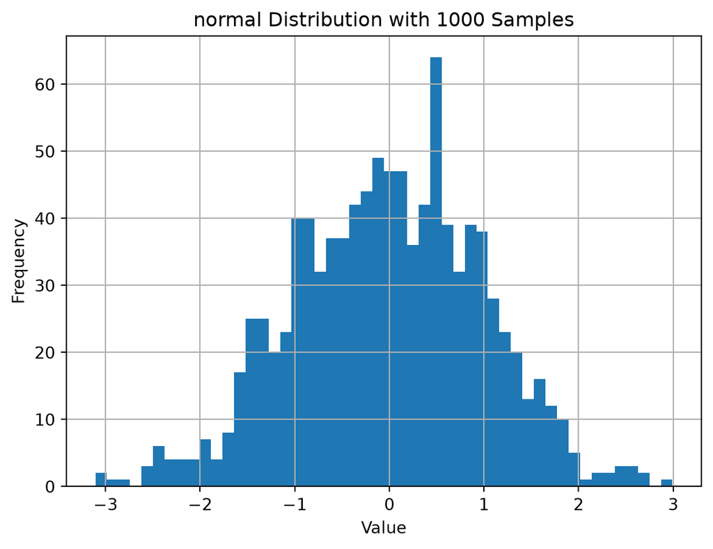

Plot of a normal distribution with 1000 samples

Your function should be able to plot at least three different types of distributions: normal, uniform, and exponential. You can use `numpy` to generate random samples from these distributions. All of the distributions should be plotted as histograms (`plt.hist`) with a corresponding frequency to show the probability density function (PDF) of the data.

ALl of the densities should be plotted as standard distributions, for example, the normal distribution should have a mean of 0 and a standard deviation of 1, the uniform distribution should be between 0 and 1, and the exponential distribution should have a scale parameter of 1.

**Note**

Some things to consider:

- Why do the distributions look different when you run the function multiple times?
- How does the number of samples affect the shape of the distribution?
- What happens if you change the parameters of the distributions (e.g., mean and standard deviation for the normal distribution)?
- Why does the histogram not quite look like the theoretical PDF of the distribution, especially for smaller sample sizes?

**Callout-answer**Answer**

```
plot_random_distribution.py
```

```python
def plot_random_distribution(distribution_type: str, num_samples: int, num_bins: int) -> None:
    """Plots a random distribution of the specified type.

    Parameters
    ----------
    distribution_type : str
        The type of distribution to plot ('normal', 'uniform', or 'exponential').
    num_samples : int
        The number of random samples to generate.
    num_bins : int
        The number of bins to use in the histogram.

    Returns
    -------
    None
    """
    if distribution_type == "normal":
        data = np.random.normal(loc=0, scale=1, size=num_samples)
    elif distribution_type == "uniform":
        data = np.random.uniform(low=0, high=1, size=num_samples)
    elif distribution_type == "exponential":
        data = np.random.exponential(scale=1, size=num_samples)
    else:
        raise ValueError("Unsupported distribution type. Use 'normal', 'uniform', or 'exponential'.")

    plt.hist(data, bins=num_bins)
    plt.title(f'{distribution_type} Distribution with {num_samples} Samples')
    plt.xlabel('Value')
    plt.ylabel('Frequency')
    plt.grid()
    plt.show()
plot_random_distribution("normal", 1000, 50)
plot_random_distribution("uniform", 1000, 50)
plot_random_distribution("exponential", 1000, 50)
```

Output

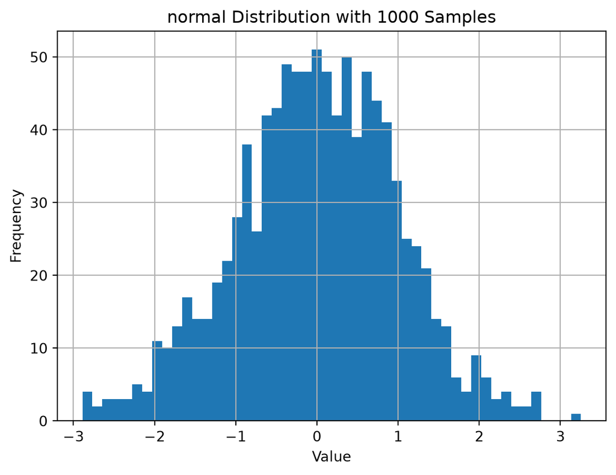

Output

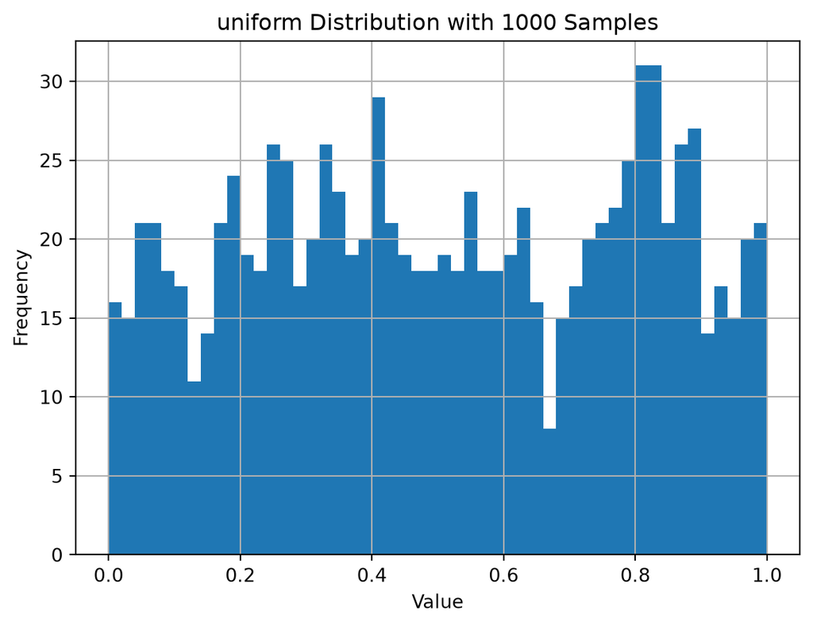

Output

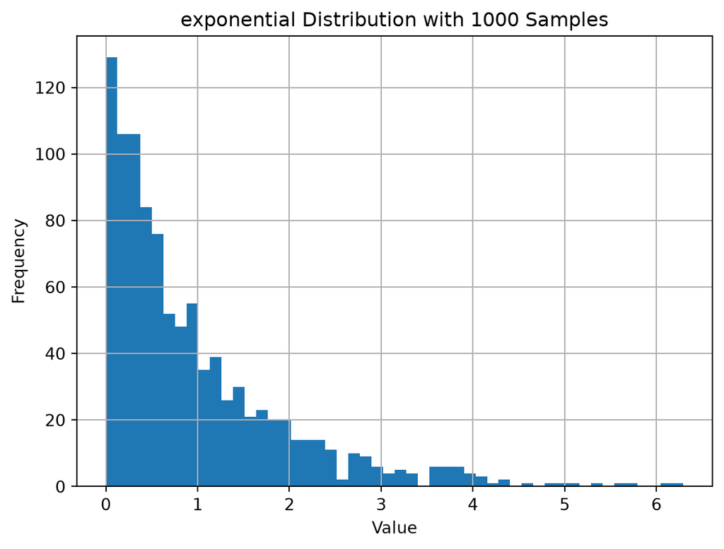